# Chapter 3: Linear Regression

#### 13

Here we’re asked to go through a simulation of the model:

$$Y=-1+X+\epsilon$$

```r
set.seed(1)

# I had to shrink the irreducible error to get the numbers closer. That makes some
# sense as if we want this to be symmetric in X & Y, they can't be that different:
q13_set = tibble(
  x = rnorm(100),
  eps = rnorm(100, sd = sqrt(0.25)),
  y = -1 + x + eps
)

# so we should be expecting a close to 1 slope and close to -1 intercept:
q13_mod = lm(
  y ~ x,
  data = q13_set
)

summary(q13_mod)
```

```
##
## Call:
## lm(formula = y ~ x, data = q13_set)
##
## Residuals:
##      Min       1Q   Median       3Q      Max
## -0.93842 -0.30688 -0.06975  0.26970  1.17309
##
## Coefficients:
##             Estimate Std. Error t value Pr(>|t|)
## (Intercept) -1.01885    0.04849  -21.01   <2e-16 ***
## x            0.99947    0.05386   18.56   <2e-16 ***
## ---
## Signif. codes:  0 '***' 0.001 '**' 0.01 '*' 0.05 '.' 0.1 ' ' 1
##
## Residual standard error: 0.4814 on 98 degrees of freedom
## Multiple R-squared:  0.7784, Adjusted R-squared:  0.7762
## F-statistic: 344.3 on 1 and 98 DF,  p-value: < 2.2e-16
```

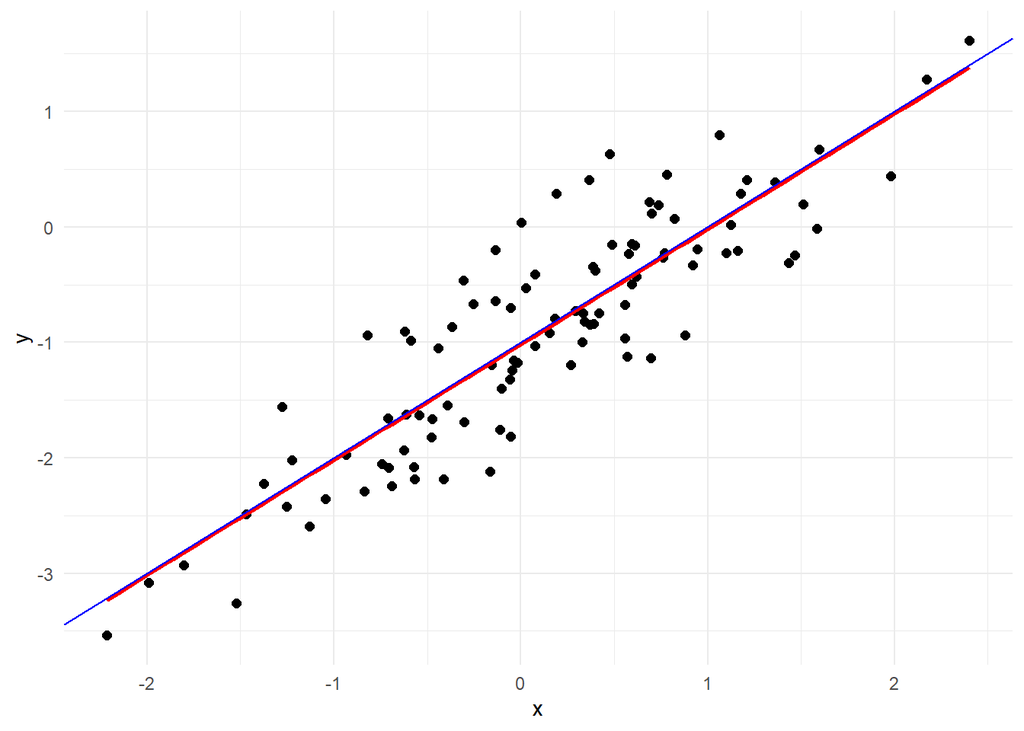

```r
ggplot(
  data = q13_set,
  aes(x = x, y = y)
) +
  geom_point(size = 2) +
  geom_smooth(
    method = 'lm',
    se = FALSE,
    color = 'red'
  ) +
  geom_abline(
    slope = 1,
    intercept = -1,
    color = 'blue'
  ) +
  theme_minimal()
```

The population and estimated models are about the same.

```r
# Now we're asked to investigate a possible quadratic term and also
# how the the models will change if we increase or decrease the variance.

q13_mod_quad = lm(
  y ~ poly(x, degree = 2),
  data = q13_set
)

summary(q13_mod_quad)
```

```
##
## Call:
## lm(formula = y ~ poly(x, degree = 2), data = q13_set)
##
## Residuals:
##      Min       1Q   Median       3Q      Max
## -0.98252 -0.31270 -0.06441  0.29014  1.13500
##
## Coefficients:
##                      Estimate Std. Error t value Pr(>|t|)
## (Intercept)           -0.9100     0.0479 -18.998   <2e-16 ***
## poly(x, degree = 2)1   8.9322     0.4790  18.647   <2e-16 ***
## poly(x, degree = 2)2  -0.6720     0.4790  -1.403    0.164
## ---
## Signif. codes:  0 '***' 0.001 '**' 0.01 '*' 0.05 '.' 0.1 ' ' 1
##
## Residual standard error: 0.479 on 97 degrees of freedom
## Multiple R-squared:  0.7828, Adjusted R-squared:  0.7784
## F-statistic: 174.8 on 2 and 97 DF,  p-value: < 2.2e-16
```

```r
anova(q13_mod, q13_mod_quad)
```

```
## Analysis of Variance Table
##
## Model 1: y ~ x
## Model 2: y ~ poly(x, degree = 2)
##   Res.Df    RSS Df Sum of Sq      F Pr(>F)
## 1     98 22.709
## 2     97 22.257  1   0.45163 1.9682 0.1638
```

```r
# not much better. What about modifying the variance down? I think that will
# just make it more evident that the square is not helpful. Let's see the other
# side.
q13_set = q13_set %>%
  mutate(
  eps2 = rnorm(100, sd = sqrt(0.5)),
  y2 = -1 + x + eps2
)

q13_mod2 = lm(
  y2 ~ x,
  data = q13_set
)

# standard error increases by about 50%
confint(q13_mod)
```

```
##                  2.5 %     97.5 %
## (Intercept) -1.1150804 -0.9226122
## x            0.8925794  1.1063602
```

```r
confint(q13_mod2)
```

```
##                  2.5 %     97.5 %
## (Intercept) -1.1275711 -0.8337236
## x            0.8517741  1.1781604
```

```r
# Fair amount wider
```

#### 14

Next we’re going to look at co-linearity. It seems like some of those side investigations I was doing as I read were kinda like the exercises. That’s okay though.

We’ll make two highly correlated predictors and then an outcome is that is a function of them jointly.

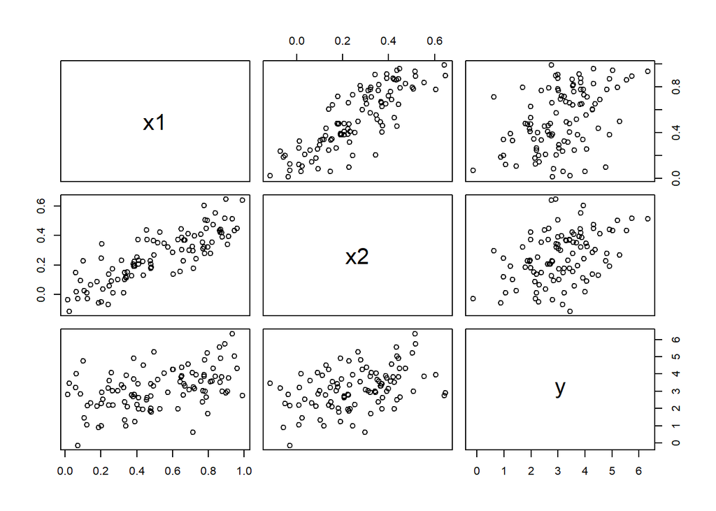

```r
set.seed(1)
q14_set = tibble(
  x1 = runif(100),
  x2 = 0.5*x1+rnorm(100)/10,
  y = 2 + 2*x1 + 0.3*x2 +rnorm(100)
)

plot(q14_set)
```

```r
cor(q14_set)
```

```
##           x1        x2         y
## x1 1.0000000 0.8351212 0.4498446
## x2 0.8351212 1.0000000 0.4199171
## y  0.4498446 0.4199171 1.0000000
```

```r
# So we have two similarly strength predictors for Y but they they're correlated.

q14_mod = lm(
  y ~ x1 + x2,
  data = q14_set
)
summary(q14_mod)
```

```
##
## Call:
## lm(formula = y ~ x1 + x2, data = q14_set)
##
## Residuals:
##     Min      1Q  Median      3Q     Max
## -2.8311 -0.7273 -0.0537  0.6338  2.3359
##
## Coefficients:
##             Estimate Std. Error t value Pr(>|t|)
## (Intercept)   2.1305     0.2319   9.188 7.61e-15 ***
## x1            1.4396     0.7212   1.996   0.0487 *
## x2            1.0097     1.1337   0.891   0.3754
## ---
## Signif. codes:  0 '***' 0.001 '**' 0.01 '*' 0.05 '.' 0.1 ' ' 1
##
## Residual standard error: 1.056 on 97 degrees of freedom
## Multiple R-squared:  0.2088, Adjusted R-squared:  0.1925
## F-statistic:  12.8 on 2 and 97 DF,  p-value: 1.164e-05
```

```r
# So the true beta1 = 2 and beta2 = 0.3 but here we find
# the estimates pushed towards eachother. We can reject the null in one case
# but not the other.

# If we do univarates:
lm(
  y ~ x1,
  data = q14_set
) %>%
  summary()
```

```
##
## Call:
## lm(formula = y ~ x1, data = q14_set)
##
## Residuals:
##      Min       1Q   Median       3Q      Max
## -2.89495 -0.66874 -0.07785  0.59221  2.45560
##
## Coefficients:
##             Estimate Std. Error t value Pr(>|t|)
## (Intercept)   2.1124     0.2307   9.155 8.27e-15 ***
## x1            1.9759     0.3963   4.986 2.66e-06 ***
## ---
## Signif. codes:  0 '***' 0.001 '**' 0.01 '*' 0.05 '.' 0.1 ' ' 1
##
## Residual standard error: 1.055 on 98 degrees of freedom
## Multiple R-squared:  0.2024, Adjusted R-squared:  0.1942
## F-statistic: 24.86 on 1 and 98 DF,  p-value: 2.661e-06
```

```r
lm(
  y ~ x2,
  data = q14_set
) %>%
  summary()
```

```
##
## Call:
## lm(formula = y ~ x2, data = q14_set)
##
## Residuals:
##      Min       1Q   Median       3Q      Max
## -2.62687 -0.75156 -0.03598  0.72383  2.44890
##
## Coefficients:
##             Estimate Std. Error t value Pr(>|t|)
## (Intercept)   2.3899     0.1949   12.26  < 2e-16 ***
## x2            2.8996     0.6330    4.58 1.37e-05 ***
## ---
## Signif. codes:  0 '***' 0.001 '**' 0.01 '*' 0.05 '.' 0.1 ' ' 1
##
## Residual standard error: 1.072 on 98 degrees of freedom
## Multiple R-squared:  0.1763, Adjusted R-squared:  0.1679
## F-statistic: 20.98 on 1 and 98 DF,  p-value: 1.366e-05
```

```r
# I am not sure whether to say this is a contradiction. It's true that the multicollinearity
# is making it so we cannot estimate the individual effects accurately in the multivariable
# model but this is a known phenomenon.

# Also a little experiment adding an outlier
sapply(q14_set, summary)
```

```
##                 x1         x2          y
## Min.    0.01339033 -0.1159936 -0.1529131
## 1st Qu. 0.32308204  0.1383549  2.3537090
## Median  0.48781071  0.2486451  3.1154811
## Mean    0.51784706  0.2571656  3.1356226
## 3rd Qu. 0.76719336  0.3762982  3.8550921
## Max.    0.99190609  0.6472348  6.3318599
```

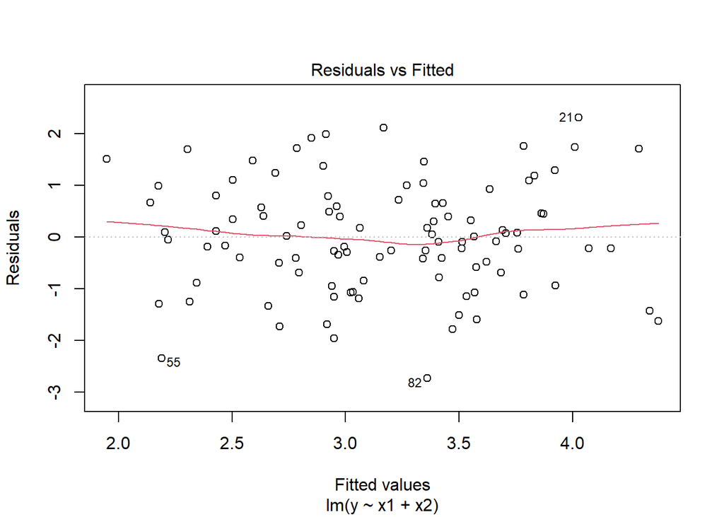

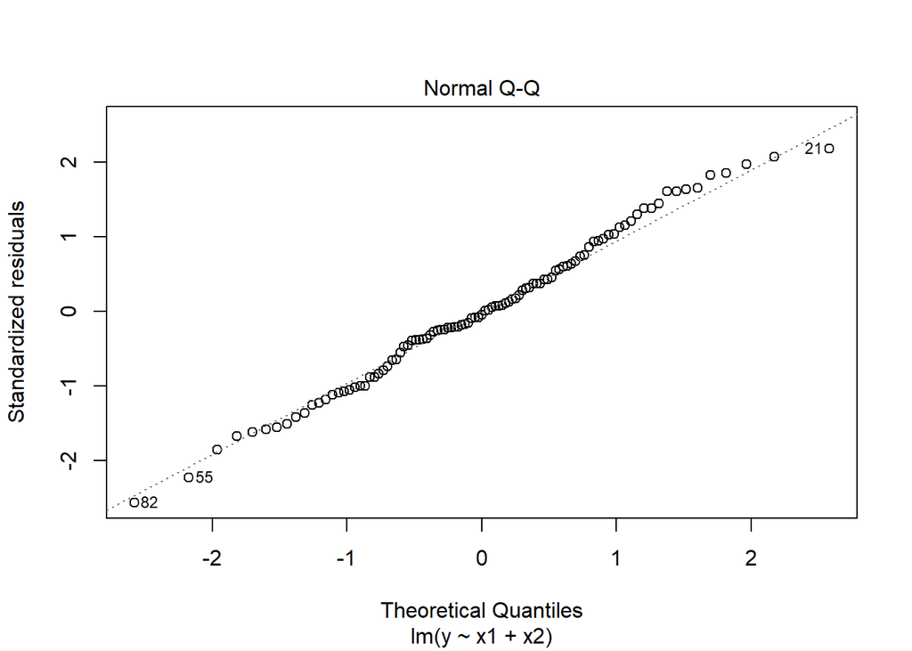

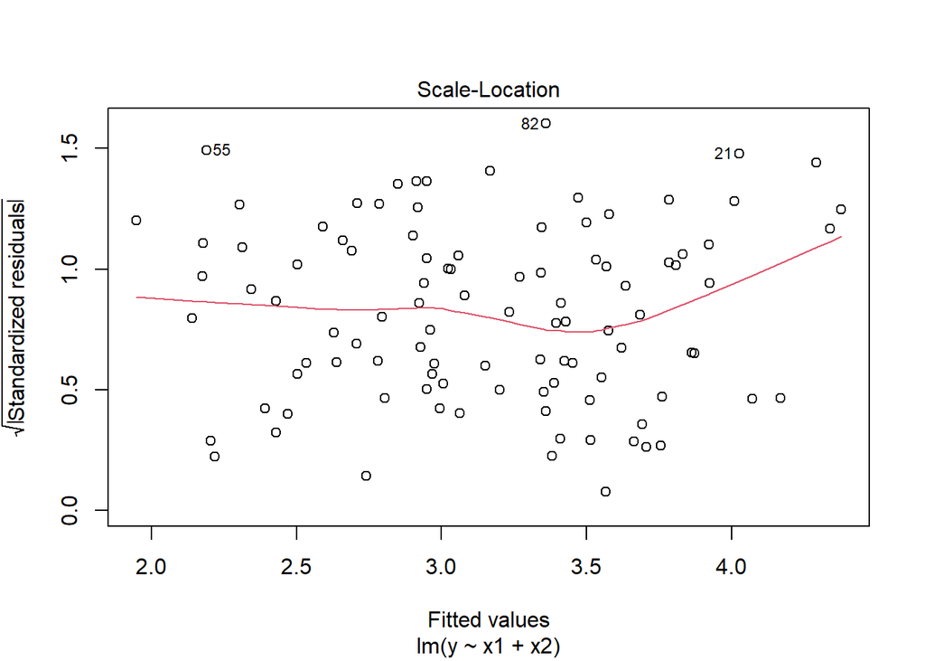

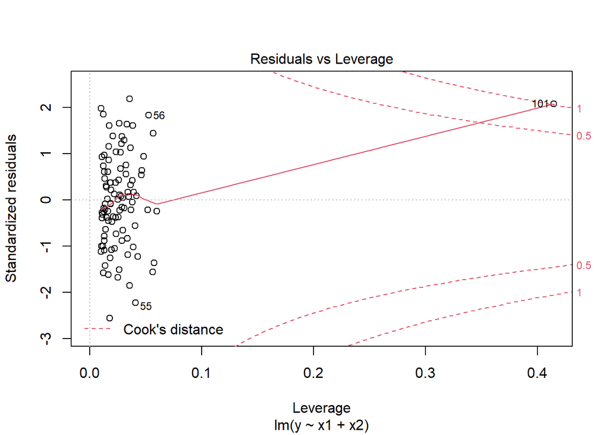

```r
q14_set = q14_set %>%
  add_row(
    x1= 0.1,
    x2 = 0.8,
    y = 6
  )

# So just from the looks of it, this should be a high leverage point but probably not an outlier
# as it's less than the maximum Y observed but well larger than the maximum X2
lm(
  y ~ x1 + x2,
  data = q14_set
) %>%
  plot()
```

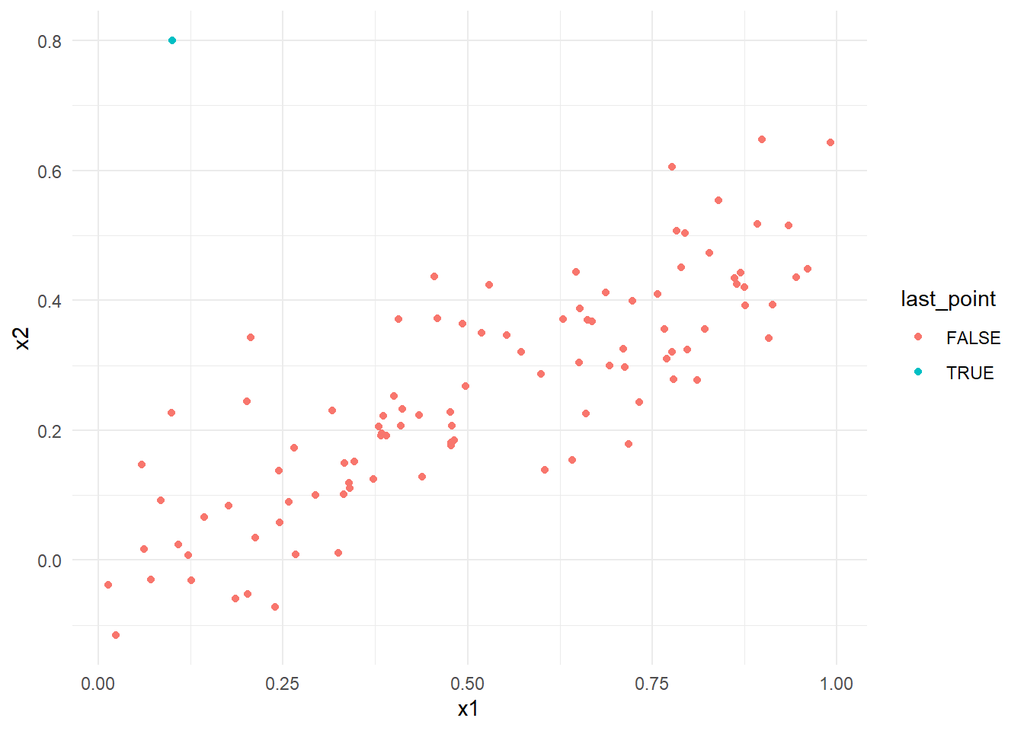

```r
# So the leverage is very large and the residual is somewhat large. With 100 obs we
# should expect about 5 to have absolute studentized residuals > 2 and that seeems about right.
q14_set %>%
  mutate(last_point = row_number() == 101) %>%
  ggplot(
    aes(x = x1, y = x2, color = last_point)
  ) +
  geom_point() +
  theme_minimal()
```

```r
# Yeah and we have the opposite trend here where x2 is large when x 1 is small giving
# further evidence that this is a high leverage point
```